## Lista 3 - SCOC7

### Davi Trost Gouveia - PC3010741

# Exercício 1.a

### Importando biblioteca e criando a função

```python
import numpy as np

# Definindo a função
def calculate_entropy(imagem):
    n = 10  # Número de símbolos utilizados

    # bincount calcula o número de ocorrencias de um valor na array
    histogram = np.bincount(imagem.flatten())

    # Calcula as probabilidades dos símbolos
    probabilities = histogram / float(imagem.size) # tamanho da array

    entropy = 0.0
    # percorre as probabilidades e realizar calcula a entropia
    for p in probabilities:
        entropy -= p * np.log2(p)  # Calcula a entropia usando a fórmula

    return entropy
```

## Imagem A

```python
imagemA = np.array([
    [9,9,9,8,9,8,9,8,8,8,8,9,9,9,9],
    [8,8,9,8,8,8,8,8,7,8,8,8,9,8,9],
    [7,7,7,6,6,7,7,7,7,6,6,6,7,8,8],
    [6,7,6,6,2,1,1,1,1,1,1,1,7,8,8],
    [7,7,6,4,3,1,0,0,0,1,2,2,6,7,8],
    [7,6,5,4,2,0,0,0,0,1,2,5,6,7,8],
    [7,7,6,6,7,6,0,0,1,6,7,7,7,8,7],
    [7,7,7,7,6,6,0,0,1,6,7,7,8,7,8],
    [7,5,8,7,6,6,0,1,1,6,7,7,7,7,8],
    [7,4,7,8,7,6,1,1,2,6,7,7,7,8,7],
    [6,6,6,7,8,7,2,2,3,6,7,6,7,7,7],
    [6,6,4,6,7,6,2,3,5,7,6,6,6,7,7],
    [6,6,3,4,6,6,6,7,7,6,6,6,6,7,7],
    [4,4,6,4,4,6,6,6,7,7,6,7,7,5,8],
    [2,3,6,6,6,4,6,7,6,7,6,6,6,7,4]
])

entropy = calculate_entropy(imagemA)
print("Entropia da imagem A: ", entropy)
```

```
Entropia da imagem A:  2.7991398248283064
```

## Imagem B

```python
imagemB = np.array([
    [0, 0, 0, 0, 0, 1, 1, 1, 1, 1],
    [0, 0, 0, 1, 0, 0, 1, 1, 3, 2],
    [0, 0, 0, 0, 1, 0, 0, 4, 3, 2],
    [0, 0, 0, 1, 5, 0, 6, 5, 4, 3],
    [0, 0, 1, 0, 6, 6, 7, 5, 4, 3],
    [0, 0, 5, 6, 9, 9, 7, 5, 4, 4],
    [1, 0, 5, 6, 8, 9, 7, 0, 4, 1],
    [2, 1, 0, 5, 6, 1, 1, 1, 1, 1],
    [1, 2, 4, 0, 5, 1, 1, 0, 1, 1],
    [2, 1, 1, 1, 1, 1, 1, 1, 1, 1]
])

entropy = calculate_entropy(imagemB)
print("Entropia da imagem B: ", entropy)
```

```
Entropia da imagem B:  2.62433220232894
```

# Exercíco 1.b

```python
import matplotlib.pyplot as plt
```

### Histograma da imagem A

```
<function matplotlib.pyplot.show(close=None, block=None)>
```

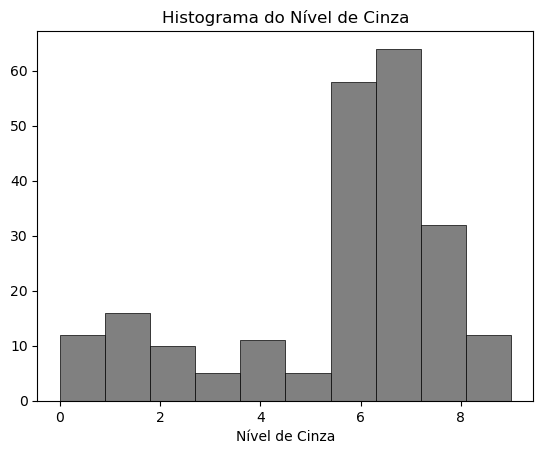

```python
histA = imagemA.flatten()

plt.hist(histA, edgecolor='black', linewidth=0.5, color='gray')
plt.xlabel('Nível de Cinza')
plt.title('Histograma do Nível de Cinza')
plt.show
```

### Imagem de A

```
<function matplotlib.pyplot.show(close=None, block=None)>
```

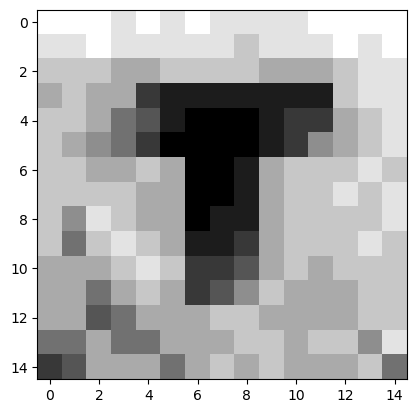

```python
plt.imshow(imagemA, cmap='gray', interpolation='nearest')
plt.show
```

### Histograma da Imagem B

```
<function matplotlib.pyplot.show(close=None, block=None)>
```

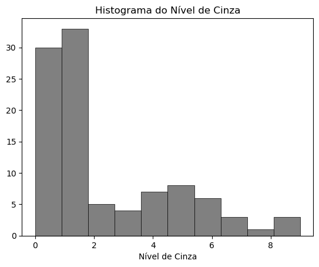

```python
histB = imagemB.flatten()

plt.hist(histB, edgecolor='black', linewidth=0.5, color='gray')
plt.xlabel('Nível de Cinza')
plt.title('Histograma do Nível de Cinza')
plt.show
```

### Imagem de B

```
<function matplotlib.pyplot.show(close=None, block=None)>
```

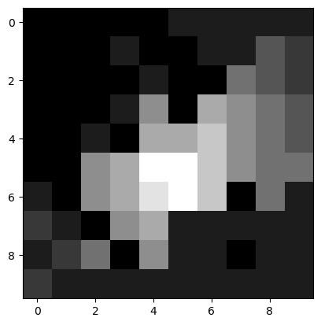

```python
plt.imshow(imagemB, cmap='gray', interpolation='nearest')
plt.show
```

# Exercício 1.c

Considerando que o resultado de H(A) = 2.7991398248283064 e de H(B) = 2.62433220232894, é possível entender que os valores são relativamente uniformes, pois são próximos mutualmente, mostrando uma maior qualidade de definição.

Pelas ordens de grandeza, percebe-se que os dois valores pertencem a mesma ordem de 10^0, isso se deve pelos valores serem de um intervalo pequeno de 0 a 9.

# Exercício 1.d

Se for feita uma correção na imagem com base no gráfico do histograma o valor da entropia será afetado. A entropia mede a aleatoriedade presente na distribuição da probabilidade, portanto, caso a imagem seja corrigida com mais informações que a definam, haverá uma maior previsibilidade dos valores e a entropia irá diminuir. O inverso acontece caso a imagem sofra uma correção que retire informações dela, nesse caso, a entropia irá aumentar e indicará que a uma maior aleatoriedade.

# Exercício 1.e

Uma imagem constituída de apenas um único nível de cinza indica que a imagem é uniforme, portanto, sua entropia será zero, pois a possuí cem por cento de previsibilidade.

Caso efetuado uma filtragem passa baixa sobre uma imagem, ocorreria uma redução dos detalhes finos e variações de intensidade, portanto, a distribuição de probabilidade dos valores de intensidade tendem a se concentrar em uma faixa menor de valor, resultando em uma menor entropia. O histograma apresentaria uma distribuição mais concentrada dos valores em relação ao original

# Exercício 2

A codificação de Huffman é um algoritmo que atribui códigos de tamanho variável a símbolos com base em suas frequências de ocorrência. A ideia é que símbolos mais frequentes recebam códigos mais curtos, enquanto símbolos menos frequentes recebem códigos mais longos, permitindo uma representação mais compacta dos dados.

Para realizar a codificação, primeiro é necessário calcular as frequências de ocorrência dos símbolos na imagem, então construir uma árvore binária de Huffman que atribui códigos aos símbolos, atribuindo 0 para os ramos esquerdos e 1 para os ramos direitos, assim que os códigos forem atribuídos, a imagem original pode ser substituída por esses valores, assim a comprimindo